# globalProject

Faizah Muthana

2025-03-05

## Link: https://www.kaggle.com/datasets/nelgiriyewithana/countries-of-the-world-2023

## About: This dataset highlights global variations across countries, covering aspects such as demographics, economic performance, environmental conditions, healthcare, education, and other key indicators. It provides a broad overview of worldwide differences and trends.

### Descriptions of variables:

#### country – name of the country

#### birth_rate – number of births per 1,000 people per year

#### life_expectancy – average number of years a person is expected to live

#### gdp – total economic output of the country

#### physicians_per_thousand – number of physicians per 1,000 people

#### maternal_mortality_ratio – number of maternal deaths per 100,000 live births

### Data types:

#### country – qualitative, nominal

#### birth_rate – quantitative, continuous

#### life_expectancy – quantitative, continuous

#### gdp – quantitative, continuous

#### physicians_per_thousand – quantitative, continuous

#### maternal_mortality_ratio – quantitative, continuous

### Motivation: I enjoy geography and wanted to compare countries to get a better understanding on how countries differ.

### Summary:

#### Birth Rate and Life Expectancy: A strong negative correlation exists between birth rate and life expectancy, indicating that countries with higher birth rates tend to have lower life expectancies. Linear regression shows that for each increase in birth rate, life expectancy decreases by about 0.66 years.

#### GDP and Life Expectancy: Wealthier countries (high GDP) generally have higher life expectancies. A t-test shows a significant difference between life expectancy in high and low GDP countries, with high GDP countries having a mean life expectancy of 78.88 years compared to 71.66 years for low GDP countries.

#### GDP and Birth Rate: High GDP countries have significantly lower birth rates compared to low GDP countries, which is confirmed by another t-test. Higher GDP countries have a mean birth rate of 11.56, while low GDP countries have a mean of 21.02.

```r
library(tidyverse)
```

```r
library(ggplot2)
library(readr)
library(dplyr)
setwd("~/Downloads/")
global <- read_csv("global.csv")
```

[output not shown]

### data cleaning

```r
global <- global %>%
  rename_all(~ gsub("[^[:alnum:]_]", "_", .))
#replace spaces & special characters with "_"
```

### Relationship Between Birth Rate and Life Expectancy

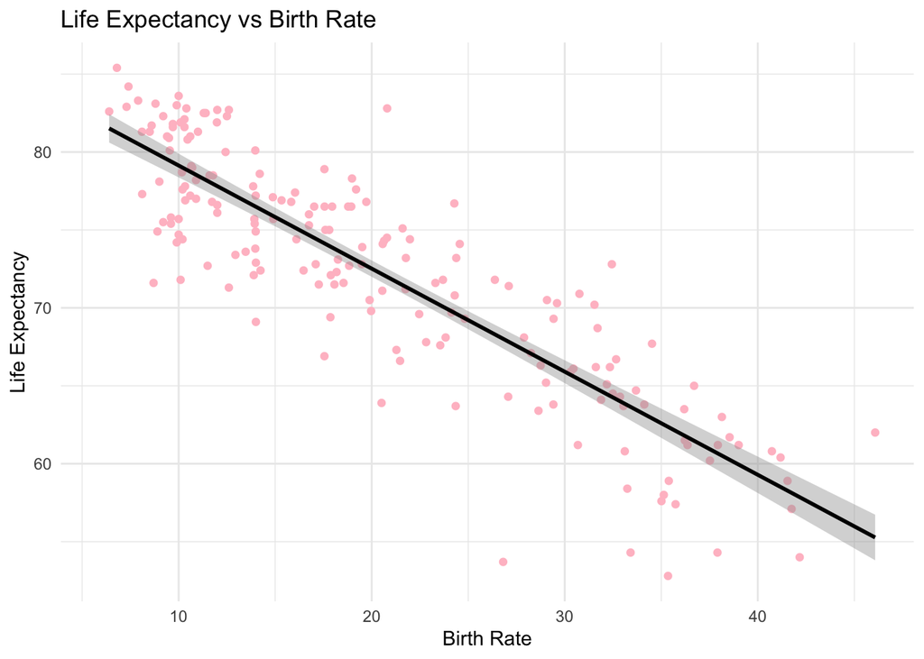

```r
#scatter plot w regression line
ggplot(global, aes(x = Birth_Rate, y = Life_expectancy)) +
  geom_point(color = "pink") +
  geom_smooth(method = "lm", color = "black") +  #linear regression line
  labs(title = "Life Expectancy vs Birth Rate",
       x = "Birth Rate",
       y = "Life Expectancy") +
  theme_minimal()
```

```r
#pearson
cor_results <- cor.test(global$Birth_Rate, global$Life_expectancy)
print(cor_results)
```

```
##
##  Pearson's product-moment correlation
##
## data:  global$Birth_Rate and global$Life_expectancy
## t = -24.553, df = 185, p-value < 2.2e-16
## alternative hypothesis: true correlation is not equal to 0
## 95 percent confidence interval:
##  -0.9046842 -0.8362161
## sample estimates:
##        cor
## -0.8747472
```

```r
#shows a strong negative link between birth rate and life expectancy (the more babies born, the shorter the life expectancy)

#linear regression model
lm_model <- lm(Life_expectancy ~ Birth_Rate, data = global)
summary(lm_model)
```

```
##
## Call:
## lm(formula = Life_expectancy ~ Birth_Rate, data = global)
##
## Residuals:
##      Min       1Q   Median       3Q      Max
## -14.3141  -2.1932   0.5413   2.4772  10.8106
##
## Coefficients:
##             Estimate Std. Error t value Pr(>|t|)
## (Intercept) 85.74759    0.60958  140.67   <2e-16 ***
## Birth_Rate  -0.66145    0.02694  -24.55   <2e-16 ***
## ---
## Signif. codes:  0 '***' 0.001 '**' 0.01 '*' 0.05 '.' 0.1 ' ' 1
##
## Residual standard error: 3.636 on 185 degrees of freedom
##   (8 observations deleted due to missingness)
## Multiple R-squared:  0.7652, Adjusted R-squared:  0.7639
## F-statistic: 602.8 on 1 and 185 DF,  p-value: < 2.2e-16
```

```r
#every time birth rate goes up by 1 unit, life expectancy drops by about 0.66 years, the modl explains 76.5% of the variation in life expectancy, and the results are statistically significant
```

### Life Expectancy by GDP Group

## data manipulation

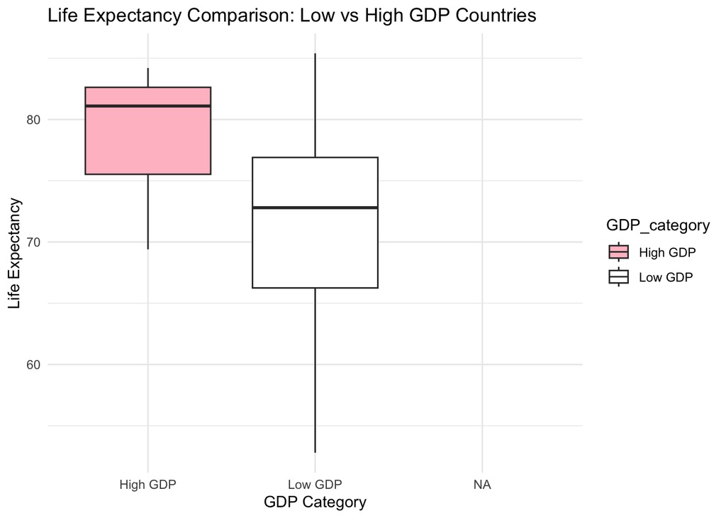

```r
#cleans the GDP and convert to numeric
global <- global %>%
  mutate(GDP_numeric = as.numeric(gsub("[\\$,]", "", GDP))) ##remove dollar signs and commas

#data manipulation
#create a new variable to classify countries into low or high gdp based on gdp_numeric
global <- global %>%
  mutate(GDP_category = ifelse(GDP_numeric < 1000000000000, "Low GDP", "High GDP"))

#boxplot
ggplot(global, aes(x = GDP_category, y = Life_expectancy, fill = GDP_category)) +
  geom_boxplot() +
  scale_fill_manual(values = c("Low GDP" = "white", "High GDP" = "pink")) +  # Custom colors
  labs(title = "Life Expectancy Comparison: Low vs High GDP Countries",
       x = "GDP Category",
       y = "Life Expectancy") +
  theme_minimal()
```

```r
#t-test
t_test_result <- t.test(Life_expectancy ~ GDP_category, data = global)
print(t_test_result)
```

```
##
##  Welch Two Sample t-test
##
## data:  Life_expectancy by GDP_category
## t = 5.504, df = 22.552, p-value = 1.442e-05
## alternative hypothesis: true difference in means between group High GDP and group Low GDP is not equal to 0
## 95 percent confidence interval:
##  4.502938 9.935586
## sample estimates:
## mean in group High GDP  mean in group Low GDP
##               78.88125               71.66199
```

```r
#p-value is much smaller than the significance level (0.05), indicating there's a significant difference between the life expectancy in high and low GDP countries
```

### Birth Rate by GDP category (Low GDP vs High GDP)

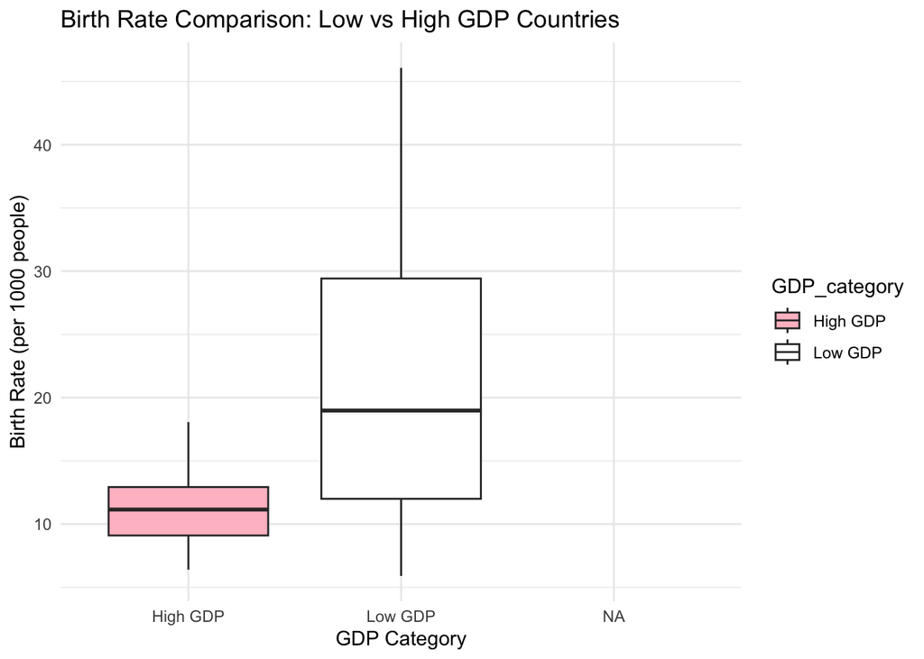

```r
#boxplot
ggplot(global, aes(x = GDP_category, y = Birth_Rate, fill = GDP_category)) +
  geom_boxplot() +
  scale_fill_manual(values = c("Low GDP" = "white", "High GDP" = "pink")) +
  labs(title = "Birth Rate Comparison: Low vs High GDP Countries",
       x = "GDP Category",
       y = "Birth Rate (per 1000 people)") +
  theme_minimal()
```

```r
#t-test
t_test_result <- t.test(Birth_Rate ~ GDP_category, data = global)
print(t_test_result)
```

```
##
##  Welch Two Sample t-test
##
## data:  Birth_Rate by GDP_category
## t = -7.8798, df = 39.938, p-value = 1.164e-09
## alternative hypothesis: true difference in means between group High GDP and group Low GDP is not equal to 0
## 95 percent confidence interval:
##  -11.881624  -7.030608
## sample estimates:
## mean in group High GDP  mean in group Low GDP
##               11.55937               21.01549
```

```r
#p-value is much smaller than the significance level (0.05), indicating theres a significant difference between the life expectancy and birth rates in high and low GDP countries
```

### Maternal Mortality and Healthcare (Physicians per Thousand)

#### not accounted for in conclusion, used to explore new data variables in the set

```r
lm_model <- lm(Maternal_mortality_ratio ~ Physicians_per_thousand, data = global)
summary(lm_model)
```

```
##
## Call:
## lm(formula = Maternal_mortality_ratio ~ Physicians_per_thousand,
##     data = global)
##
## Residuals:
##     Min      1Q  Median      3Q     Max
## -226.85 -108.30  -44.47   48.55  846.51
##
## Coefficients:
##                         Estimate Std. Error t value Pr(>|t|)
## (Intercept)              296.644     20.031  14.809   <2e-16 ***
## Physicians_per_thousand  -78.806      8.233  -9.571   <2e-16 ***
## ---
## Signif. codes:  0 '***' 0.001 '**' 0.01 '*' 0.05 '.' 0.1 ' ' 1
##
## Residual standard error: 181 on 178 degrees of freedom
##   (15 observations deleted due to missingness)
## Multiple R-squared:  0.3398, Adjusted R-squared:  0.3361
## F-statistic: 91.61 on 1 and 178 DF,  p-value: < 2.2e-16
```

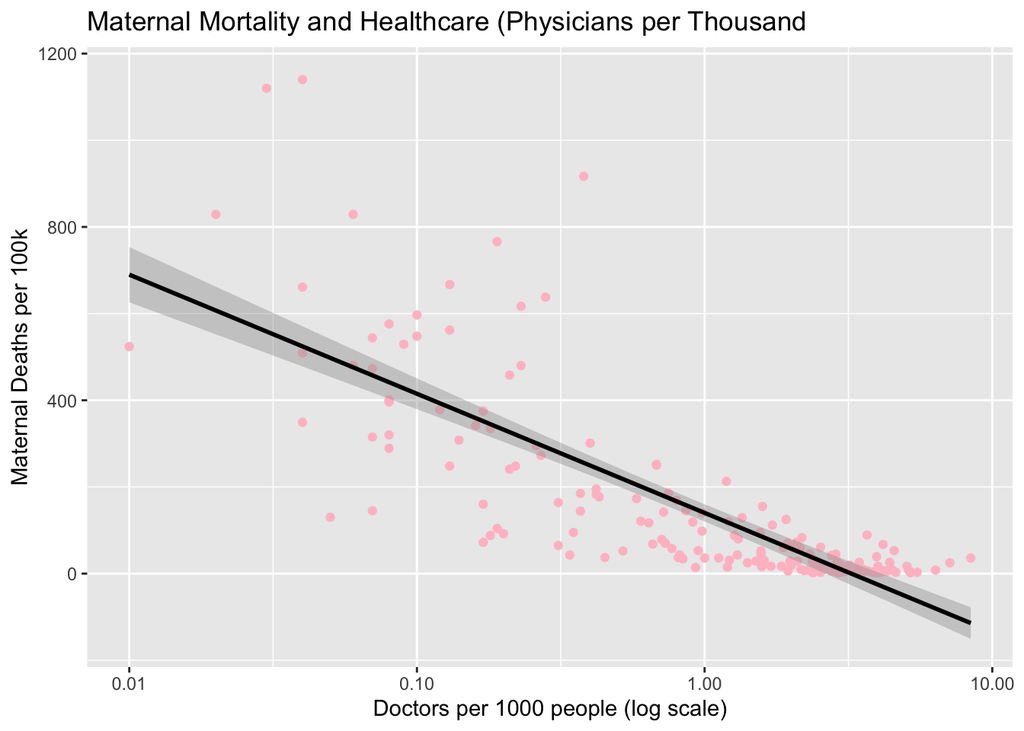

```r
global %>%
  ggplot(aes(x = Physicians_per_thousand, y = Maternal_mortality_ratio)) +
  geom_point(color = "pink") +
  scale_x_log10() + # for skewed data
  geom_smooth(method = "lm", color = "black") + # adding regression line
  labs(title = "Maternal Mortality and Healthcare (Physicians per Thousand", x = "Doctors per 1000 people (log scale)", y = "Maternal Deaths per 100k")
```

```r
#p-value: < 2.2e-16 suggests a significant relationship between physicians per thousand and maternal mortality
```

## Conclusion: Life expectancy is closely associated with both GDP and birth rate. Wealthier countries tend to have higher GDP, longer life expectancies, and lower birth rates. In contrast, countries with lower GDP often experience shorter life expectancies and higher birth rates. This trend suggests that wealthier nations provide better living conditions, healthcare, and more controlled population growth, contributing to longer lifespans. However, it’s important to note that this is a correlation, not a causal relationship, and other factors may also influence these outcomes.